# First Step(s) into Knowledge Discovery

17 10 2019

## 1. Reading Structured Dataset

- Not Shown:
  - Acquiring data with the assumption: time series have in the same row the same time
  - Generating Structured dataset which is human-readable but also usable in any programming language
  - Making sure that time series are equally spaced
  - Time series are in the same time resolution (regular time series)

```r
V = TSAT::ReadDates('ScandinavianElectricityPrices.csv', InDirectory = inpath)
```

```
## [1] "The follwing comments were in the file:"
## [1] " sys - system price it disregards physical capacity limitations between nordic bitting areas while the capacity limitations in/oput nordic are considered.                    the system price for each hour is based on the intersection of the aggregated supply and demand curves representing al…
```

```r
DF = as.data.frame(V)
#transform to R object defining the time
FullTime = strptime(paste(as.character(DF$Time), DF$Hours), '%Y-%m-%d %H', tz = 'UTC')
#splite time ffrom data an make sure that data is numeric
Data = as.matrix(DF[, -c(1, 2)])
mode(Data) = "numeric"
```

## 1.1 Data Quality Check - Missing Values

- Check for missing values

  => One variable is deleted (“LV”)

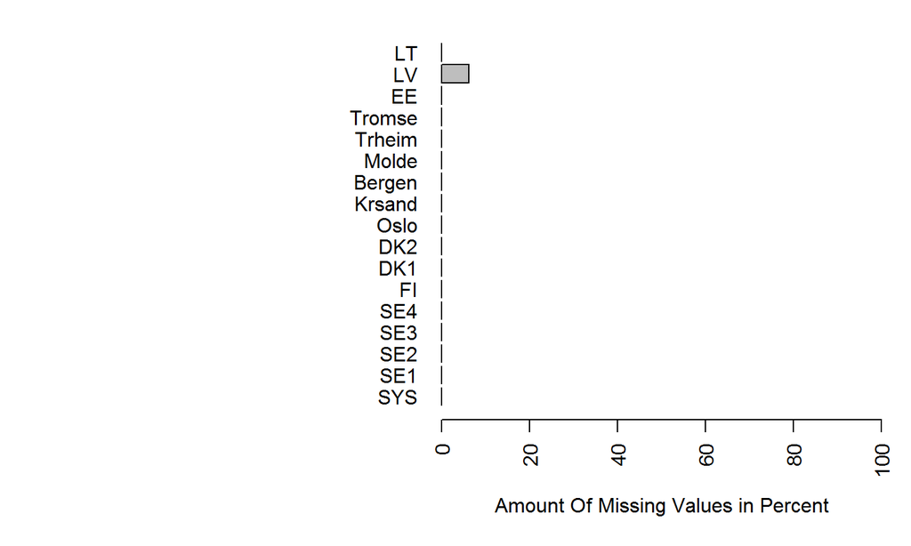

```r
DataVisualizations::PlotMissingvalues(Data)
```

## 1.2 Data Quality Check - Expected Range

- Range of data is not as expected (negative prices!) but domain expert is unavailable

  => Two variables are disregarded (“DK1” “DK2”)

```r
Data = Data[, -16]#LV
apply(Data, 2, range, na.rm = T)
```

```
##         SYS    SE1    SE2    SE3    SE4     FI     DK1    DK2   Oslo
## [1,]   1.14   0.12   0.12   0.12   0.12   0.12  -62.03 -62.03   0.59
## [2,] 199.97 255.02 255.02 255.02 255.02 255.02 2000.00 255.02 255.02
##      Krsand Bergen  Molde Trheim Tromse     EE     LT
## [1,]   0.59   0.59   1.14   1.14   1.38   0.12   0.12
## [2,] 114.70 114.70 255.02 255.02 255.02 255.02 300.01
```

```r
Data = Data[, -c(7, 8)]#"DK1" "DK2"
```

## 2.1 First Look into Patterns

- x-axis: Time per hour as index
- y-axis: names of variables
- All values in same interval of 0-100 with some outliers above

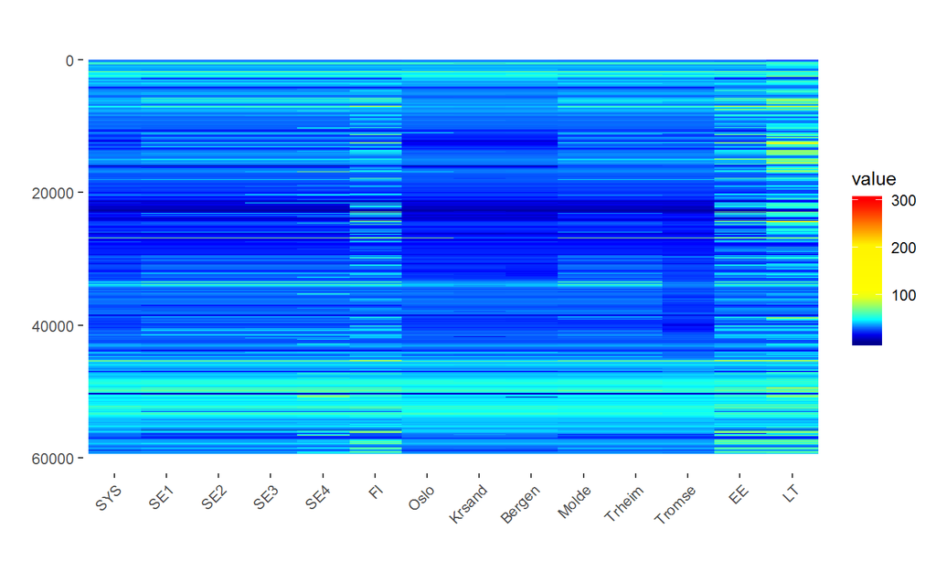

```r
DataVisualizations::Pixelmatrix(Data)
```

```r
FullTime[1]
```

```
## [1] "2013-01-01 UTC"
```

```r
FullTime[20000]
```

```
## [1] "2015-04-14 05:00:00 UTC"
```

```r
FullTime[50000]
```

```
## [1] "2018-09-15 02:00:00 UTC"
```

## 2.2 Interpretation of the Pixelmatrix

- SE1, SE2, SE3 show the same patterns => probable directly correlated without any lag
  - Same is true for Molde and Trheim
- There is a small period with high values (2013), followed by a longer time period with low values (~2015) and then one with high values (~2018)

  => Its possible that cyclic component in the range of years exists
- Note, decomposition model can have the patterns: Trend, Cyclical component, seasonality, irregular component

  => Discuss with domain expert!

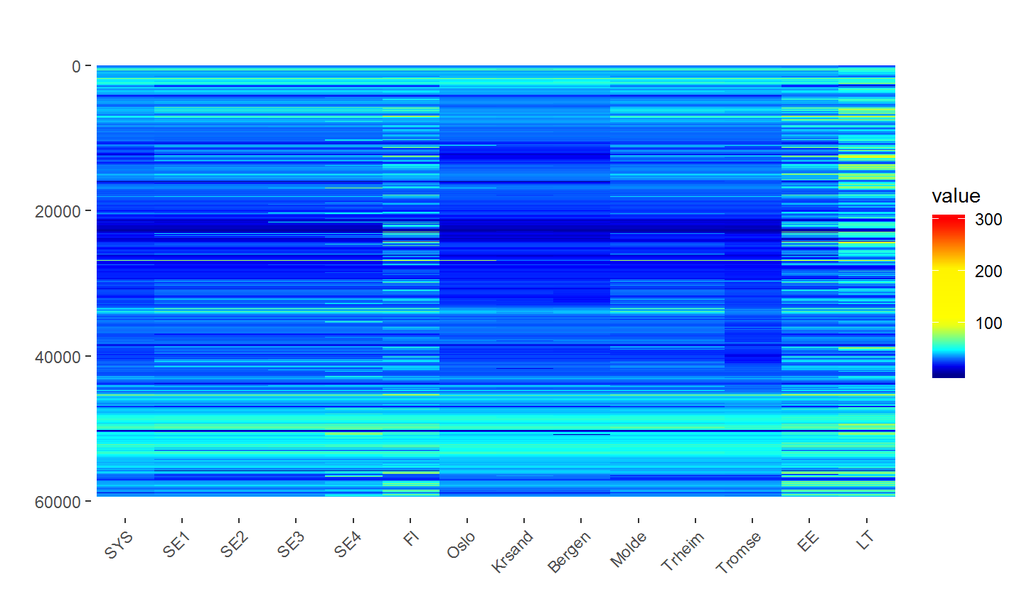

```r
DataVisualizations::Pixelmatrix(Data)
```

## 2.3 Imputation of Missing Values - Code

- Is there a small amount of non finite values left?

```r
apply(Data,2,
  FUN = function(x)
    return(sum(!is.finite(x)))
)
```

```
##    SYS    SE1    SE2    SE3    SE4     FI   Oslo Krsand Bergen  Molde
##      7      7      7      7      7      7      7      7      7      7
## Trheim Tromse     EE     LT
##      7      7      7      7
```

```r
ind = which(!is.finite(Data[, 'SYS']))
#Data[ind,]
FullTime[ind]
```

```
## [1] "2013-03-31 02:00:00 UTC" "2014-03-30 02:00:00 UTC"
## [3] "2015-03-29 02:00:00 UTC" "2016-03-27 02:00:00 UTC"
## [5] "2017-03-26 02:00:00 UTC" "2018-03-25 02:00:00 UTC"
## [7] "2019-03-31 02:00:00 UTC"
```

```r
#Forward Fill
Data[ind, ] = Data[ind - 1, ]
```

## 2.4 Imputation of Missing Values - Interpretation

- Strange behavior of missing values
- Without prior knowledge we assume that price is given until a new price is set (Forward Filling)
- In general, imputation is a complex task, e.g. for LV feature
- Sometimes outliers have to be disregarded, or replaced, e.g. “DK1” “DK2”

  => To be discussed with domain expert!

## 3 Data Wrangling and Preprocessing

- Takes always some time and in time series its often challenging
- Due to time limitation we restrict the first step in KD to the target variable “Sys”
  - see comments in header of dataset (printed above)
- For forecasting, we assume that the trend is the average of the last week (168) hours.
- Look into the details at home

## 3.1 Exemplary Preprocessing

- Prepare Trend for whole data but make sure to only use past data for present trend
  - Trend is the moving average of the last 168 values
- Restructure_Split() transforms each element in a list from a vector to a data-frame

```r
Target = Data[, 'SYS']
#right side of window is the last point in time
#meaning that the mean is only computed backwards
#important for later foracasting
Trend = RcppRoll::roll_mean(Target, 168, align = "right")
Trend = c(rep(Trend[1], length(Target) - length(Trend)), Trend)
#plot(Target,type='l')
#points(Trend,type='l',col='red')
# For Saisonanlity split into training and test data
# Do not investigate Test Data!
# Reason: In reality test data is not available at the point
# of forecasting
year = lubridate::year(FullTime)
start = min(which(year == 2018))
Target = Data[1:(start - 1), 'SYS']
TargetDetrended = Target - Trend[1:(start - 1)]
Restructure_Split = function(Liste) {
  #Function transforms each element in a list from a vector to a dataframe
  #implicit assumption: regular time series, time series is sorted
  return(lapply(Liste, function(x) {
    hours = 1:25
    n = length(x)
    x = t(as.matrix(x))
    colnames(x) = hours[1:n]
    DF = as.data.frame(x)
    return(DF)
  }))
}
```

## 3.2 Compute Weekly Seasonality

- It seems, I forgot the winter/summer clock change!

```r
#split time series into seven time series, one per day
#week starts on monday
days = lubridate::wday(FullTime, week_start = 1)
#on element per day
SysPerDay = c()
for (i in 1:7) {
  #a week has 7 days
  ind_mo = which(days == i)
  wTime = FullTime[ind_mo]
  wData = TargetDetrended[ind_mo]
  Time = cut(wTime, breaks = "days")
  wSYS = split(x = wData, f = Time, drop = T)
  wSYS_df = Restructure_Split(wSYS)
  #dataframes can be combined according to names of features
  #if features does not exist, nan are imputed
  SysPerDay[[i]] = data.table::rbindlist(l = wSYS_df, fill = TRUE)
}
# number of days w.r.t to specific weekdays
# number of hours in the weekdays
sapply(SysPerDay, dim)
```

```
##      [,1] [,2] [,3] [,4] [,5] [,6] [,7]
## [1,]  353  354  354  353  353  353  353
## [2,]   24   24   24   24   24   24   25
```

## 3.3 Visualize Weekly Seasonality

- Plotly can be used for interactive visualizations
- It should also preferred to really look (and zoom!) into the time series you investigate (not shown in this presentation)

```r
AverageWeek = unlist(lapply(SysPerDay, function(x)
  apply(x, 2, median, na.rm = T)))

p <- plotly::plot_ly()
p <-
  plotly::add_lines(
    p,
    x = 1:length(AverageWeek),
    y = ~ AverageWeek + mean(Trend),
    name = 'Mondays'
  )
p <-  plotly::layout(
  p,
  title = '"Sys" Variable Seasonality Pattern: Week',
  xaxis = list(title = 'Mo-So in Hours'),
  yaxis = list(title = 'Euro/MWh',
               showgrid = FALSE)
)
```

## 3.4 Weekly Seasonality

- In hourly resolution the pattern is clearly visible
- Does the domain expert expect this behavior?

-> Needs discussion

```r
p
```

[interactive chart not shown]

## 3.5 Stability of Seasonality

- Again a little bit of data wrangling (-> home work) results in density plot

```r
X = c()#hours
Y = c()#price
#restructe data to two vectors
for (i in 1:7) {
  x = SysPerDay[[i]]
  x$Id = 1:nrow(x)
  dfmweek = reshape2::melt(x, id = "Id")
  dfmweek$variable = as.numeric(as.character(dfmweek$variable))
  #hours are consecutive from 1..168 representing a week
  X = c(X, dfmweek$variable + (i - 1) * 24)#
  Y = c(Y, dfmweek$value)
}
#pareto density estimations
out = DataVisualizations::PDEscatter(
  X,
  Y,
  na.rm = T,
  ylim = c(min(Y, na.rm = T), 65),
  PlotIt = FALSE,
  xlab = 'Mo-So in Hours',
  ylab = "Euro/MWh",
  main = 'Density Estimation of Seasonality Pattern',
  DrawTopView = FALSE,
  Plotter = 'plotly'
)
```

## 3.6 Seasonality Pattern Still Visible in Density Plot

- Two dimensions are hours and electricity prices
- Third dimension (z-axis) the density (probability of the weekly seasonality)

```r
#restricting range to relevant part
plotly::layout(out$Handle, scene = list(yaxis = list(range = c(0, 12))))
```

[interactive chart not shown]

## 3.7 Excurs: Building Simple Decomposition Model

- Model= Trend + Weekly-Seasonality
  - Trend: moving average of last 168 hours
  - Seasonality is restricted to the average weekly pattern

=> Very simple model!

-> Code details are homework

```r
n = floor(nrow(Data) / 168)
weekdays = c(rep(1, 24),
             rep(2, 24),
             rep(3, 24),
             rep(4, 24),
             rep(5, 24),
             rep(6, 24),
             rep(7, 24))
DF_AverageWeek = data.frame(
  AverageWeekPrice = AverageWeek[1:168],
  FullHours = 1:168,
  HourOfDay = rep(0:23, 7),
  DayOfWeek = weekdays
)
days = lubridate::wday(FullTime, week_start = 1)
hours = lubridate::hour(FullTime)
startingpoint = which(DF_AverageWeek$DayOfWeek == days[1] &
                        DF_AverageWeek$HourOfDay == hours[1])
SeasonTooLong = c(DF_AverageWeek$AverageWeekPrice[startingpoint:168],
                  rep(DF_AverageWeek$AverageWeekPrice, n))
DecompositionModel_simple = Trend + SeasonTooLong[1:length(Trend)]
```

## 3.8 Excurs: Verifying Model

- We expect that this model does not perform that well because residuals are not normally distributed

=> There is still information left in the residuals

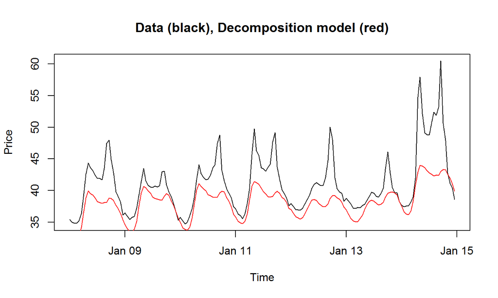

```r
plot(
  FullTime[169:(168 * 2)],
  Data[169:(168 * 2), 'SYS'],
  type = 'l',
  xlab = 'Time',
  main = 'Data (black), Decomposition model (red)',
  ylab = 'Price'
)
points(FullTime[169:(168 * 2)],
       DecompositionModel_simple[169:(168 * 2)],
       type = 'l',
       col = 'red')
```

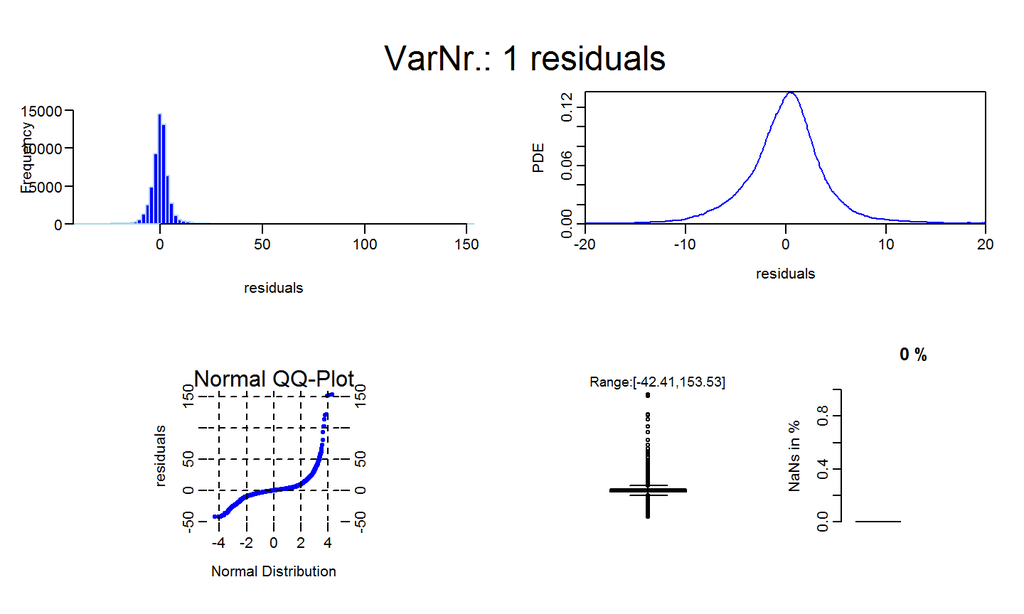

```r
# residuum should be normally distributed
DataVisualizations::InspectVariable(Data[,'SYS']-DecompositionModel_simple,N = 'residuals',xlim = c(-20,20))
```

## 4. Conclusion

- “Exploratory data analysis is detective work” [Tukey, 1977, p.2].
- “As all detective stories remind us, many of the circumstances surrounding a crime are accidental or misleading. Equally, many of the indications to be discerned in bodies of data are accidental or misleading [Tukey, 1977, p.3].”

=> Play the role of the detective

=> Use many different approaches of knowledge discovery

=> Believe the visualizations/statistic only if several approaches yield the same result

=> We implicitly have now a “simple” decomposition model in forecasting with a weekly seasonality pattern!

=> The simple model will serve as baseline

## Supplementary Information: Saving Data

```r
setwd(outpath)
Season = SeasonTooLong[1:length(Trend)]
save(file = 'PreparedDataAndWeeklySaisonality.rda',
     DF_AverageWeek,
     Data,
     FullTime,
     DecompositionModel_simple,
     Trend,
     Season)
```